# Scotch Whisky에서 Body감을 높이기 위한 Blending Model

#### Body감은 술이 입 안에서 들어왔을 때의 묵직한 정도를 의미

#### 와인같은 경우에는 알콜 함량 5%~15%/Vol.로 알콜 함량의 스펙트럼이 넓어서 알콜 함량이 높을 수록

#### body감이 높아진다고 할 수 있지만 whisky에서는 대부분 40±α%/Vol이므로 알콜도수만으로 Body감이

#### 정해지지 않는다고 판단해서 숙성시킴에 있어 증류소만의 다른 향이 Whisky의 Body감에 영향을 미치는지에

#### 대해 알고 싶어 주제를 선정

```python
import numpy as np
import pandas as pd
import scipy as sp
from scipy import stats

from matplotlib import pyplot as plt
import seaborn as sns
sns.set()

import statsmodels.formula.api as smf
import statsmodels.api as sm

%precision 3
%matplotlib inline
```

```python
Distillery = pd.read_csv('Distillery.csv', encoding='utf-8')
```

```python
Distillery.head(5)
```

|  | RowID | Distillery | Body | Sweetness | Smoky | Medicinal | Tobacco | Honey | Spicy | Winey | Nutty | Malty | Fruity | Floral | Postcode | Latitude | Longitude |
| --- | --- | --- | --- | --- | --- | --- | --- | --- | --- | --- | --- | --- | --- | --- | --- | --- | --- |
| 0 | 1 | Aberfeldy | 2 | 2 | 2 | 0 | 0 | 2 | 1 | 2 | 2 | 2 | 2 | 2 | \tPH15 2EB | 286580 | 749680 |
| 1 | 2 | Aberlour | 3 | 3 | 1 | 0 | 0 | 4 | 3 | 2 | 2 | 3 | 3 | 2 | \tAB38 9PJ | 326340 | 842570 |
| 2 | 3 | AnCnoc | 1 | 3 | 2 | 0 | 0 | 2 | 0 | 0 | 2 | 2 | 3 | 2 | \tAB5 5LI | 352960 | 839320 |
| 3 | 4 | Ardbeg | 4 | 1 | 4 | 4 | 0 | 0 | 2 | 0 | 1 | 2 | 1 | 0 | \tPA42 7EB | 141560 | 646220 |
| 4 | 5 | Ardmore | 2 | 2 | 2 | 0 | 0 | 1 | 1 | 1 | 2 | 3 | 1 | 1 | \tAB54 4NH | 355350 | 829140 |

```python
Distillery.describe()
```

|  | RowID | Body | Sweetness | Smoky | Medicinal | Tobacco | Honey | Spicy | Winey | Nutty | Malty | Fruity | Floral | Latitude | Longitude |
| --- | --- | --- | --- | --- | --- | --- | --- | --- | --- | --- | --- | --- | --- | --- | --- |
| count | 86.000000 | 86.000000 | 86.000000 | 86.000000 | 86.000000 | 86.000000 | 86.000000 | 86.000000 | 86.000000 | 86.000000 | 86.000000 | 86.000000 | 86.000000 | 86.000000 | 8.600000e+01 |
| mean | 43.500000 | 2.069767 | 2.290698 | 1.534884 | 0.546512 | 0.116279 | 1.244186 | 1.383721 | 0.976744 | 1.465116 | 1.802326 | 1.802326 | 1.697674 | 287247.162791 | 8.026597e+05 |
| std | 24.969982 | 0.930410 | 0.717287 | 0.863613 | 0.990032 | 0.322439 | 0.853175 | 0.784686 | 0.932760 | 0.821730 | 0.629094 | 0.779438 | 0.855017 | 67889.046814 | 8.802422e+04 |
| min | 1.000000 | 0.000000 | 1.000000 | 0.000000 | 0.000000 | 0.000000 | 0.000000 | 0.000000 | 0.000000 | 0.000000 | 0.000000 | 0.000000 | 0.000000 | 126680.000000 | 5.542600e+05 |
| 25% | 22.250000 | 2.000000 | 2.000000 | 1.000000 | 0.000000 | 0.000000 | 1.000000 | 1.000000 | 0.000000 | 1.000000 | 1.000000 | 1.000000 | 1.000000 | 265672.500000 | 7.556975e+05 |
| 50% | 43.500000 | 2.000000 | 2.000000 | 1.000000 | 0.000000 | 0.000000 | 1.000000 | 1.000000 | 1.000000 | 2.000000 | 2.000000 | 2.000000 | 2.000000 | 319515.000000 | 8.398850e+05 |
| 75% | 64.750000 | 2.000000 | 3.000000 | 2.000000 | 1.000000 | 0.000000 | 2.000000 | 2.000000 | 1.000000 | 2.000000 | 2.000000 | 2.000000 | 2.000000 | 328630.000000 | 8.507700e+05 |
| max | 86.000000 | 4.000000 | 4.000000 | 4.000000 | 4.000000 | 1.000000 | 4.000000 | 3.000000 | 4.000000 | 4.000000 | 3.000000 | 3.000000 | 4.000000 | 381020.000000 | 1.009260e+06 |

#### 가설 - 바디감에 큰 요소를 미치는 것은 술에 있어서 가향적인 부분이 아닌 증류적인 부분에서 큰 영향을 받기 때문에

#### 술에 무언가 인위적으로 첨가를 하는 Sweeetness(Saramel 등), Medicinal(Herb 류), Honey, Spicy(Spice), Nutty(Nut),

#### Fruity(Citrus), Floral(Rose, Bigaradier 등)이 아니라 Whisky의 원료가 되는 맥주의 Malty함 및 숙성하면서 배어나오는

#### 오크통의 Smoky함, 그리고 Body감의 스펙트럼이 제일 넓은 와인의 느낌을 담은 Winey함이 영향을 미치는 데에

#### 가장 큰 요소가 될 것으로 예상함.

#### Body감이 높다는 기준을 최고점인 4점이 아닌 한단계 아래인 3점을 포함한 3,4점을 Body감이 높다고 판단한다.

```python
Distillery.drop(columns='Postcode', inplace=True)
```

```python
Distillery['Bodyfeel'] = [1 if i>=3 else 0 for i in Distillery.Body]
```

## 각 독립변수의 로지스틱회귀곡선

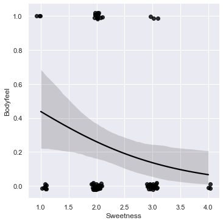

```python
sns.lmplot(x = "Sweetness", y = "Bodyfeel",
           data = Distillery,
           logistic = True,
           scatter_kws = {"color": "black"},
           line_kws    = {"color": "black"},
           x_jitter = 0.1, y_jitter = 0.02)
```

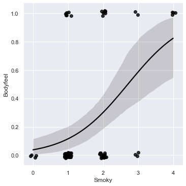

```python
sns.lmplot(x = "Smoky", y = "Bodyfeel",
           data = Distillery,
           logistic = True,
           scatter_kws = {"color": "black"},
           line_kws    = {"color": "black"},
           x_jitter = 0.1, y_jitter = 0.02)
```

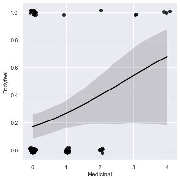

```python
sns.lmplot(x = "Medicinal", y = "Bodyfeel",
           data = Distillery,
           logistic = True,
           scatter_kws = {"color": "black"},
           line_kws    = {"color": "black"},
           x_jitter = 0.1, y_jitter = 0.02)
```

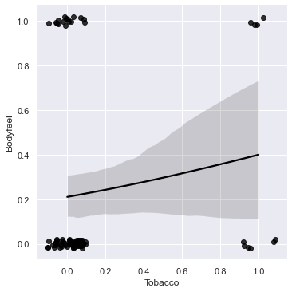

```python
sns.lmplot(x = "Tobacco", y = "Bodyfeel",
           data = Distillery,
           logistic = True,
           scatter_kws = {"color": "black"},
           line_kws    = {"color": "black"},
           x_jitter = 0.1, y_jitter = 0.02)
```

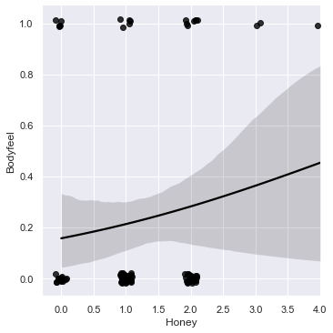

```python
sns.lmplot(x = "Honey", y = "Bodyfeel",
           data = Distillery,
           logistic = True,
           scatter_kws = {"color": "black"},
           line_kws    = {"color": "black"},
           x_jitter = 0.1, y_jitter = 0.02)
```

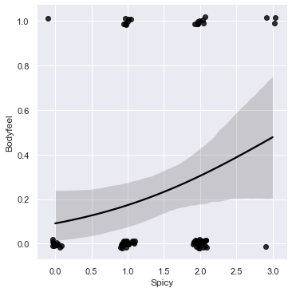

```python
sns.lmplot(x = "Spicy", y = "Bodyfeel",
           data = Distillery,
           logistic = True,
           scatter_kws = {"color": "black"},
           line_kws    = {"color": "black"},
           x_jitter = 0.1, y_jitter = 0.02)
```

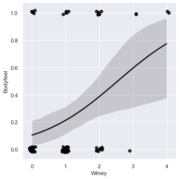

```python
sns.lmplot(x = "Winey", y = "Bodyfeel",
           data = Distillery,
           logistic = True,
           scatter_kws = {"color": "black"},
           line_kws    = {"color": "black"},
           x_jitter = 0.1, y_jitter = 0.02)
```

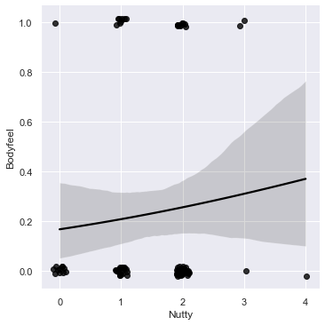

```python
sns.lmplot(x = "Nutty", y = "Bodyfeel",
           data = Distillery,
           logistic = True,
           scatter_kws = {"color": "black"},
           line_kws    = {"color": "black"},
           x_jitter = 0.1, y_jitter = 0.02)
```

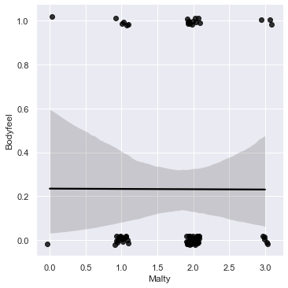

```python
sns.lmplot(x = "Malty", y = "Bodyfeel",
           data = Distillery,
           logistic = True,
           scatter_kws = {"color": "black"},
           line_kws    = {"color": "black"},
           x_jitter = 0.1, y_jitter = 0.02)
```

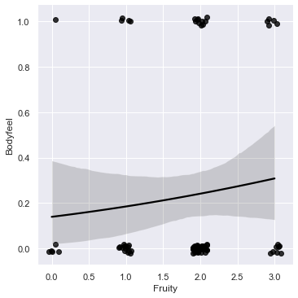

```python
sns.lmplot(x = "Fruity", y = "Bodyfeel",
           data = Distillery,
           logistic = True,
           scatter_kws = {"color": "black"},
           line_kws    = {"color": "black"},
           x_jitter = 0.1, y_jitter = 0.02)
```

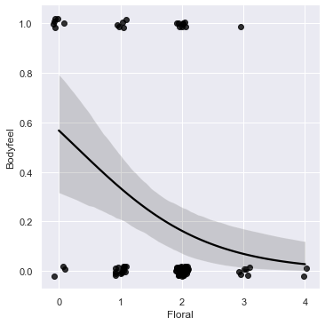

```python
sns.lmplot(x = "Floral", y = "Bodyfeel",
           data = Distillery,
           logistic = True,
           scatter_kws = {"color": "black"},
           line_kws    = {"color": "black"},
           x_jitter = 0.1, y_jitter = 0.02)
```

## 각 독립변수를 이용한 모델링

```python
model_sweet = smf.glm(formula='Bodyfeel~Sweetness', data=Distillery, family=sm.families.Binomial()).fit()
model_smoky = smf.glm(formula='Bodyfeel~Smoky', data=Distillery, family=sm.families.Binomial()).fit()
model_medicinal = smf.glm(formula='Bodyfeel~Medicinal', data=Distillery, family=sm.families.Binomial()).fit()
model_tobacco = smf.glm(formula='Bodyfeel~Tobacco', data=Distillery, family=sm.families.Binomial()).fit()
model_honey = smf.glm(formula='Bodyfeel~Honey', data=Distillery, family=sm.families.Binomial()).fit()
model_spicy = smf.glm(formula='Bodyfeel~Spicy', data=Distillery, family=sm.families.Binomial()).fit()
model_winey = smf.glm(formula='Bodyfeel~Winey', data=Distillery, family=sm.families.Binomial()).fit()
model_nutty = smf.glm(formula='Bodyfeel~Nutty', data=Distillery, family=sm.families.Binomial()).fit()
model_malty = smf.glm(formula='Bodyfeel~Malty', data=Distillery, family=sm.families.Binomial()).fit()
model_fruity = smf.glm(formula='Bodyfeel~Fruity', data=Distillery, family=sm.families.Binomial()).fit()
model_floral = smf.glm(formula='Bodyfeel~Floral', data=Distillery, family=sm.families.Binomial()).fit()
```

```python
[model_sweet.summary(),
model_smoky.summary(),
model_medicinal.summary(),
model_tobacco.summary(),
model_honey.summary(),
model_spicy.summary(),
model_winey.summary(),
model_nutty.summary(),
model_malty.summary(),
model_fruity.summary(),
model_floral.summary()]
```

```
[<class 'statsmodels.iolib.summary.Summary'>
 """
                  Generalized Linear Model Regression Results
 ==============================================================================
 Dep. Variable:               Bodyfeel   No. Observations:                   86
 Model:                            GLM   Df Residuals:                       84
 Model Family:                Binomial   Df Model:                            1
 Link Function:                  logit   Scale:                          1.0000
 Method:                          IRLS   Log-Likelihood:                -44.401
 Date:                Sat, 05 Jun 2021   Deviance:                       88.803
 Time:                        19:38:35   Pearson chi2:                     82.9
 No. Iterations:                     4
 Covariance Type:            nonrobust
 ==============================================================================
                  coef    std err          z      P>|z|      [0.025      0.975]
 ------------------------------------------------------------------------------
 Intercept      0.5441      0.861      0.632      0.527      -1.143       2.231
 Sweetness     -0.7946      0.392     -2.029      0.043      -1.562      -0.027
 ==============================================================================
 """,
 <class 'statsmodels.iolib.summary.Summary'>
 """
                  Generalized Linear Model Regression Results
 ==============================================================================
 Dep. Variable:               Bodyfeel   No. Observations:                   86
 Model:                            GLM   Df Residuals:                       84
 Model Family:                Binomial   Df Model:                            1
 Link Function:                  logit   Scale:                          1.0000
 Method:                          IRLS   Log-Likelihood:                -39.152
 Date:                Sat, 05 Jun 2021   Deviance:                       78.304
 Time:                        19:38:35   Pearson chi2:                     84.8
 No. Iterations:                     5
 Covariance Type:            nonrobust
 ==============================================================================
                  coef    std err          z      P>|z|      [0.025      0.975]
 ------------------------------------------------------------------------------
 Intercept     -3.2240      0.688     -4.687      0.000      -4.572      -1.876
 Smoky          1.1901      0.349      3.414      0.001       0.507       1.873
 ==============================================================================
 """,
```

[output cut: 165 more lines]

```
 Model:                            GLM   Df Residuals:                       84
 Model Family:                Binomial   Df Model:                            1
 Link Function:                  logit   Scale:                          1.0000
 Method:                          IRLS   Log-Likelihood:                -42.059
 Date:                Sat, 05 Jun 2021   Deviance:                       84.117
 Time:                        19:38:35   Pearson chi2:                     88.5
 No. Iterations:                     4
 Covariance Type:            nonrobust
 ==============================================================================
                  coef    std err          z      P>|z|      [0.025      0.975]
 ------------------------------------------------------------------------------
 Intercept      0.2730      0.543      0.503      0.615      -0.791       1.337
 Floral        -0.9558      0.335     -2.857      0.004      -1.612      -0.300
 ==============================================================================
 """]
```

```python
{'aic':[model_smoky.aic, model_winey.aic, model_medicinal.aic, model_spicy.aic],
'llf':[model_smoky.llf, model_winey.llf, model_medicinal.llf, model_spicy.llf]}
```

```
{'aic': [82.30354342114076,
  87.80703317584977,
  91.29417718132937,
  92.79849280578004],
 'llf': [-39.15177171057038,
  -41.903516587924884,
  -43.64708859066469,
  -44.39924640289002]}
```

##### 위 4가지 독립 요소들을 AIC, 로그우도 면에서 봤을 때 Smoky -> Winey -> Medicinal -> Spicy 순으로 우수한 모델임을 알 수 있다.

##### (단일 독립변수 기준)

```python
model0 = smf.glm(formula='Bodyfeel~Smoky', data=Distillery, family=sm.families.Binomial()).fit()
model1 = smf.glm(formula='Bodyfeel~Smoky+Winey', data=Distillery, family=sm.families.Binomial()).fit()
model2 = smf.glm(formula='Bodyfeel~Smoky+Winey+Medicinal', data=Distillery, family=sm.families.Binomial()).fit()
model3 = smf.glm(formula='Bodyfeel~Smoky+Winey+Medicinal+Spicy', data=Distillery, family=sm.families.Binomial()).fit()

[model0.aic, model1.aic, model2.aic, model3.aic]
```

```
[82.30354342114076, 71.28017329332963, 72.75563919210434, 72.62482056502851]
```

##### aic값을 비교했을 때 model1, 즉 smoky함과 winey함을 가진 모델이 가장 우수하다.

```python
model1.summary()
```

Generalized Linear Model Regression Results

| Dep. Variable: | Bodyfeel | No. Observations: | 86 |
| --- | --- | --- | --- |
| Model: | GLM | Df Residuals: | 83 |
| Model Family: | Binomial | Df Model: | 2 |
| Link Function: | logit | Scale: | 1.0000 |
| Method: | IRLS | Log-Likelihood: | -32.640 |
| Date: | Sat, 05 Jun 2021 | Deviance: | 65.280 |
| Time: | 17:29:55 | Pearson chi2: | 78.6 |
| No. Iterations: | 5 |  |  |
| Covariance Type: | nonrobust |  |  |

|  | coef | std err | z | P>\|z\| | [0.025 | 0.975] |
| --- | --- | --- | --- | --- | --- | --- |
| Intercept | -5.0838 | 1.053 | -4.826 | 0.000 | -7.149 | -3.019 |
| Smoky | 1.4876 | 0.404 | 3.683 | 0.000 | 0.696 | 2.279 |
| Winey | 1.1332 | 0.358 | 3.165 | 0.002 | 0.431 | 1.835 |

### model1(Smoky & Winey)에서의 계수, Deviance잔차, Pearson잔차

```python
model1.params
```

```
Intercept   -5.083796
Smoky        1.487650
Winey        1.133180
dtype: float64
```

```python
np.sum(model1.resid_deviance ** 2)
```

```
65.28017329332961
```

```python
np.sum(model1.resid_pearson ** 2)
```

```
78.60313100628062
```

## 생성한 모델인 model1을 사용해 Distillery 데이터에서 Body감을 예측한다.

```python
Distillery['predicted_Body'] = np.where(model1.predict(Distillery)>=0.5, 1, 0)
Distillery['err'] = np.where(Distillery.predicted_Body==Distillery.Bodyfeel,True,False)
```

```python
Distillery[['Body', 'Smoky', 'Winey', 'Bodyfeel', 'predicted_Body', 'err']]
```

|  | Body | Smoky | Winey | Bodyfeel | predicted_Body | err |
| --- | --- | --- | --- | --- | --- | --- |
| 0 | 2 | 2 | 2 | 0 | 1 | False |
| 1 | 3 | 1 | 2 | 1 | 0 | False |
| 2 | 1 | 2 | 0 | 0 | 0 | True |
| 3 | 4 | 4 | 0 | 1 | 1 | True |
| 4 | 2 | 2 | 1 | 0 | 0 | True |
| ... | ... | ... | ... | ... | ... | ... |
| 81 | 1 | 1 | 0 | 0 | 0 | True |
| 82 | 2 | 2 | 1 | 0 | 0 | True |
| 83 | 0 | 1 | 1 | 0 | 0 | True |
| 84 | 2 | 1 | 1 | 0 | 0 | True |
| 85 | 2 | 0 | 1 | 0 | 0 | True |

86 rows × 6 columns

```python
Distillery.err.mean()
```

```
0.8372093023255814
```

## 결과

#### Whisky에서는 Smoky함과 Winey함에 의해 Body감이 올라간다고 예측할 수 있으며, 특히 Smoky는 오크통에서

#### 오래 숙성시킬수록 풍부해지는 경향이 있기 때문에 숙성 연수가 높은 Whisky일수록 더 묵직한 Body감을 느낄 수 있을 것이다.

#### Winey함은 가설에서 말했던 것 처럼 Body감에 영향을 미치는 것으로 보이지만 Malty를 단일 독립변수로 사용한 모델의

#### Wald검정 p-value가 0.05 이상이었다는 점에서 Malty함이 Whisky의 Body감에 영향을 미치지 못하는 것으로 보인다.

#### 그 이유로는 맥주 자체의 Body감의 스펙트럼이 와인만큼 넓지 않고, Malty함이 맥주의 풍미를 전부 담당하는 것은

#### 아니기 때문이라 생각하고 이에 대해서는 차후에 분석할 예정이다.